# Project_1_HW

Jake Peters

10/5/2021

This dataset is a measure of US air pollution from 2000 to 2006. I will be looking at daily pollution measures of Ozone, or O3, in Phoenix, Arizona, measured once for each day from 2000 to 2006. This data is taken from https://www.kaggle.com/sogun3/uspollution.

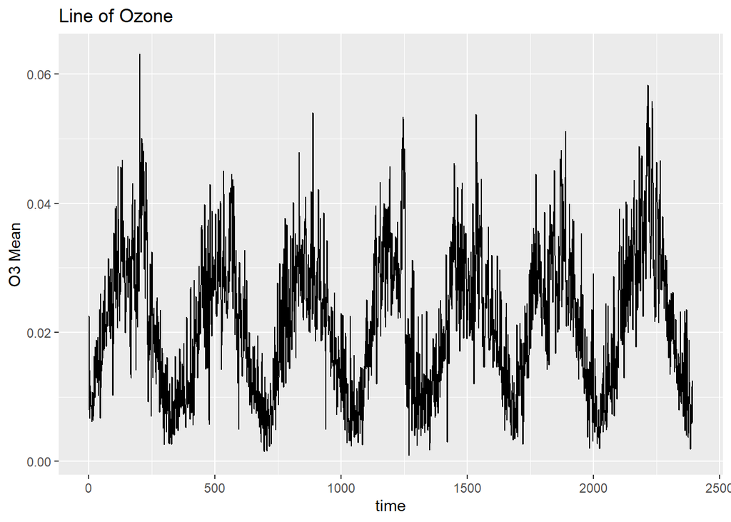

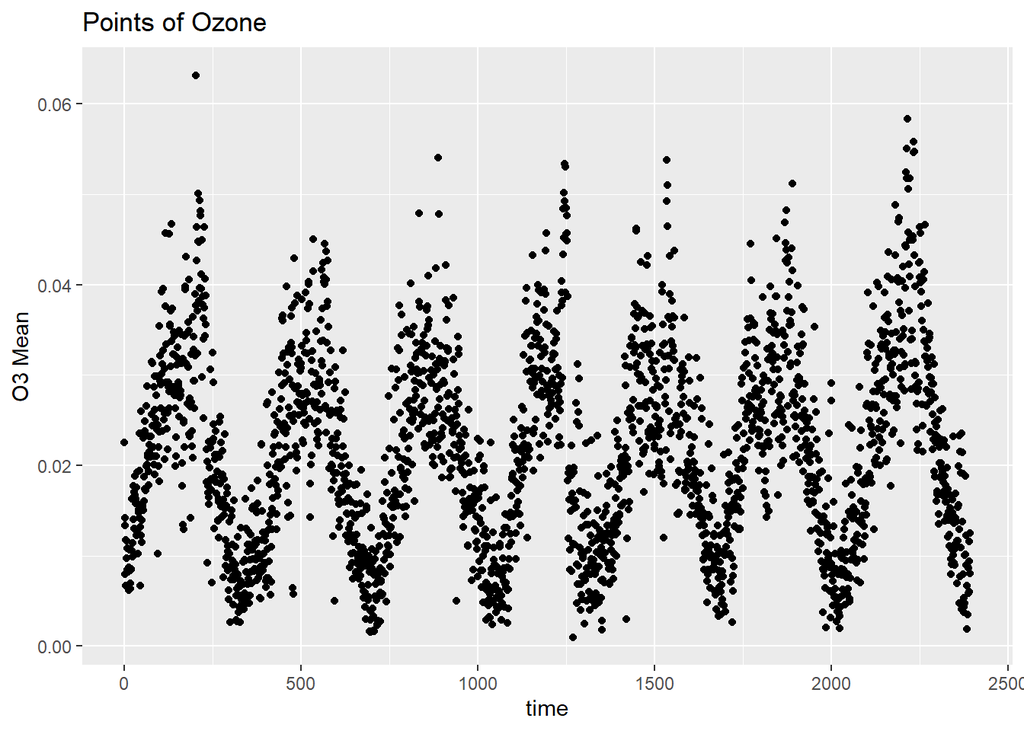

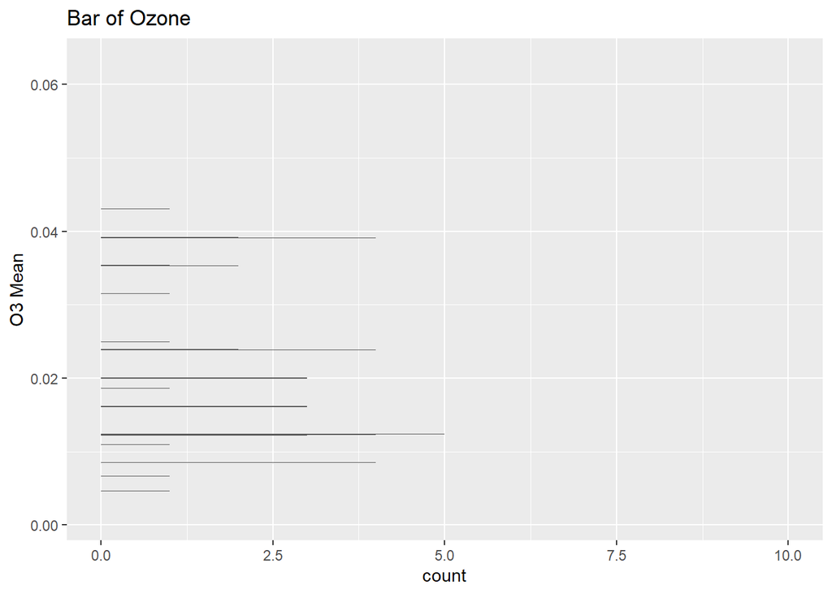

It does not look like this data needs transforming. It does not funnel outward during the events of the time series. It looks like it mostly stays consistent in its deviation from the average throughout the series. However, it also looks like there is plenty of seasonality in the Ozone data. This could be measured by setting the h values of our forecasts to 365, or the number of days in a year, so that the forecasts are comparing to data from previous years.

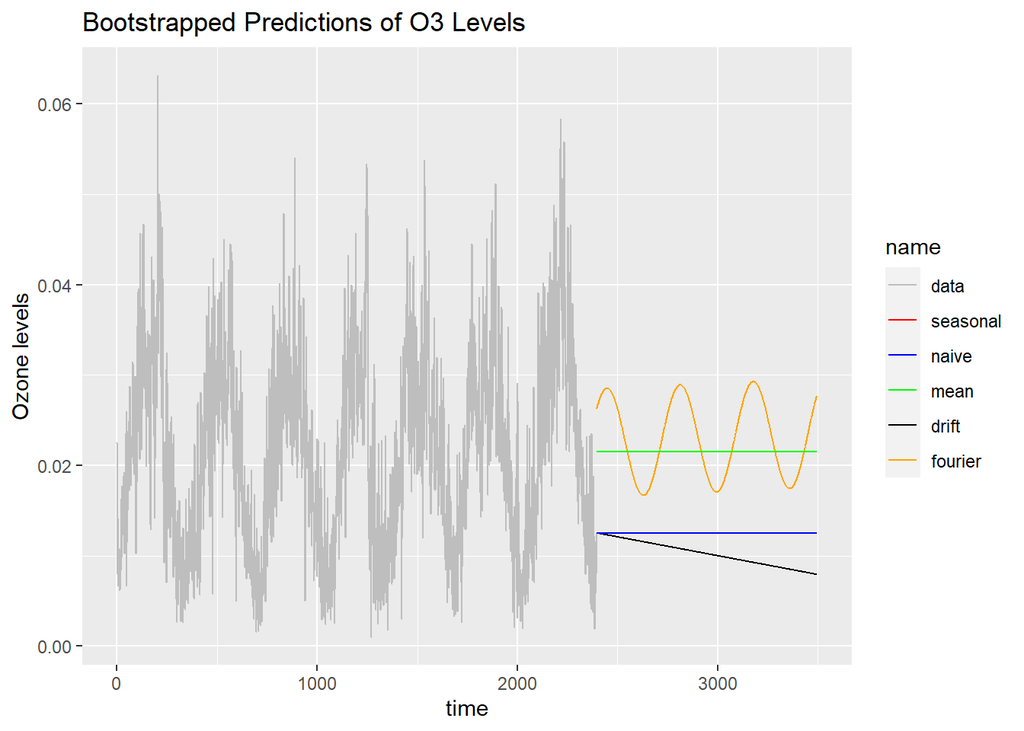

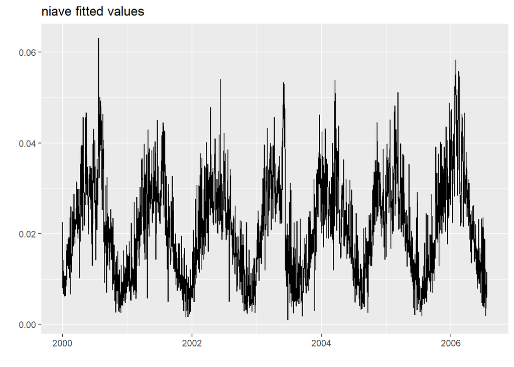

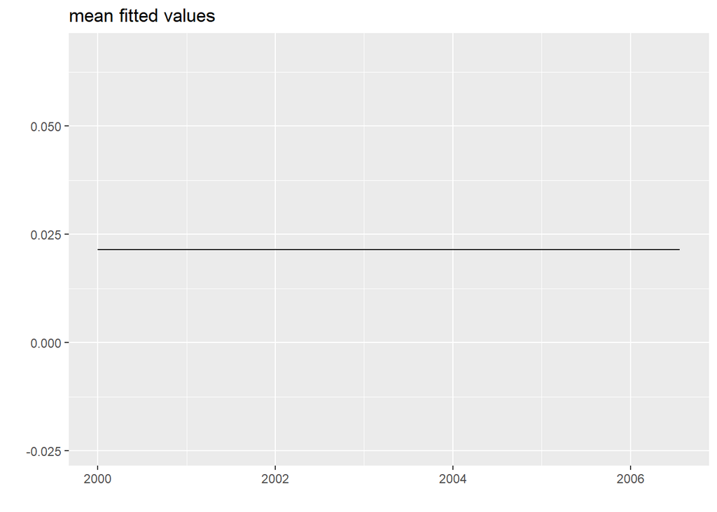

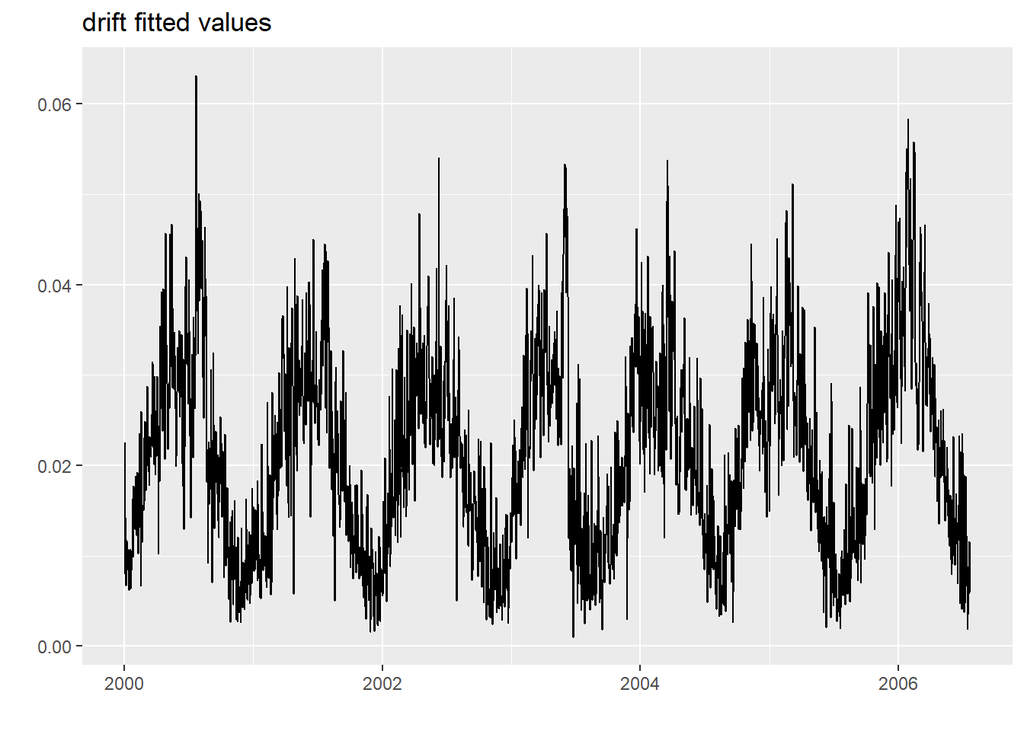

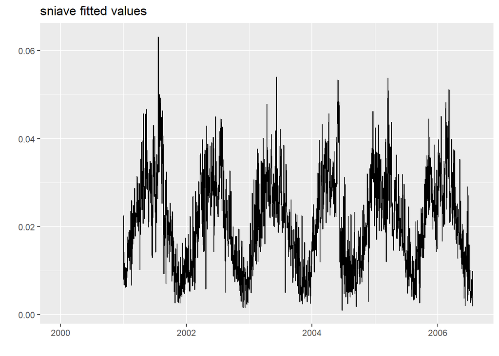

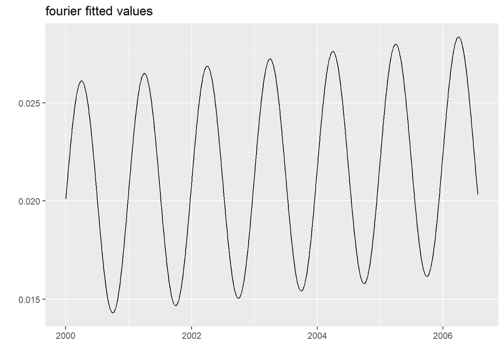

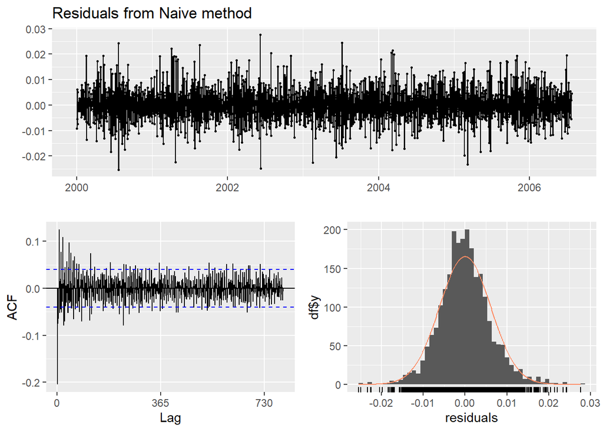

```
##
##  Ljung-Box test
##
## data:  Residuals from Naive method
## Q* = 1086, df = 479, p-value < 2.2e-16
##
## Model df: 0.   Total lags used: 479
```

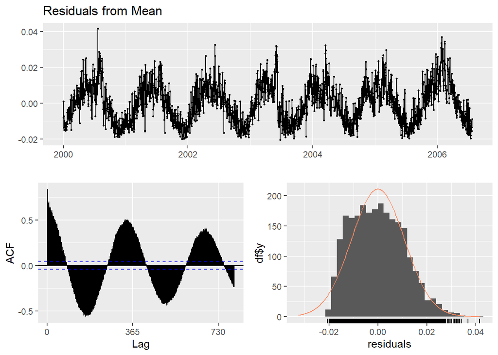

```
##
##  Ljung-Box test
##
## data:  Residuals from Mean
## Q* = 170773, df = 478, p-value < 2.2e-16
##
## Model df: 1.   Total lags used: 479
```

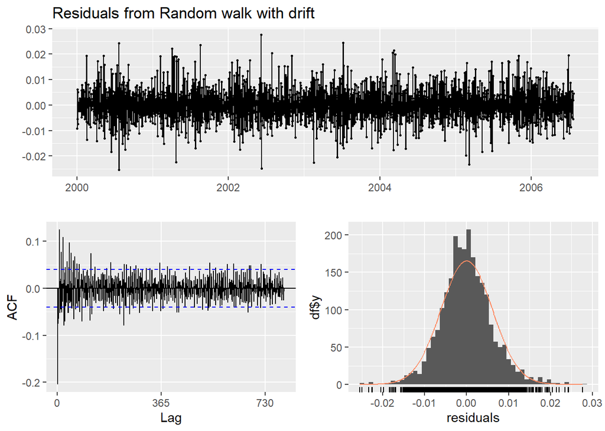

```
##
##  Ljung-Box test
##
## data:  Residuals from Random walk with drift
## Q* = 1086, df = 478, p-value < 2.2e-16
##
## Model df: 1.   Total lags used: 479
```

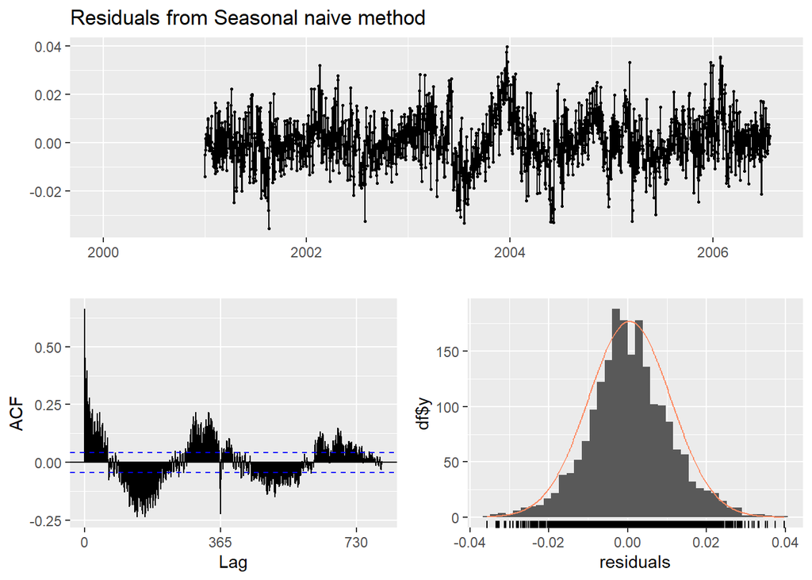

```
##
##  Ljung-Box test
##
## data:  Residuals from Seasonal naive method
## Q* = 16271, df = 479, p-value < 2.2e-16
##
## Model df: 0.   Total lags used: 479
```

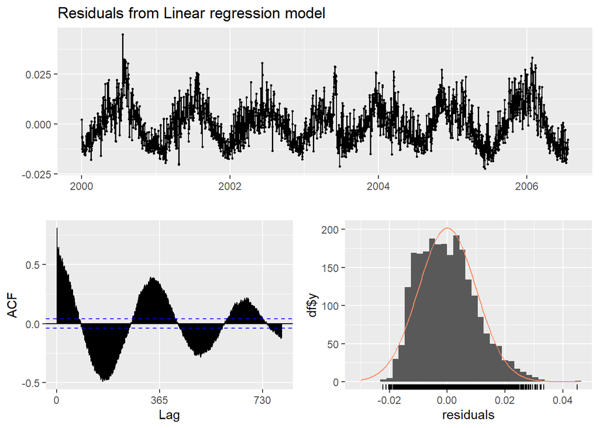

```
##
##  Ljung-Box test
##
## data:  Residuals from Linear regression model
## Q* = 119455, df = 475, p-value < 2.2e-16
##
## Model df: 4.   Total lags used: 479
```

These residuals are not residuals we would desire in a forecast. They are all way too correlated, with some looking like they could have some extra patterns to be parceled out as well. However, the means of the residuals are each at about zero, which is what is desired, meaning they are not biased. For variance, it is certainly not constant, and in some cases is actually wave-shaped, indicative of underlying patterns. The residuals are mostly normally distributed, though, which I think points more to the sheer amount of data than to actual well-performing residuals. These are garbage residuals which tell us that our models (and forecasts, eventually) are not very good, which is indicative of the simplicity of the models. The residuals imply that the prediction intervals will probably be inaccurate as well as being larger because of the greater uncertainty in the data.

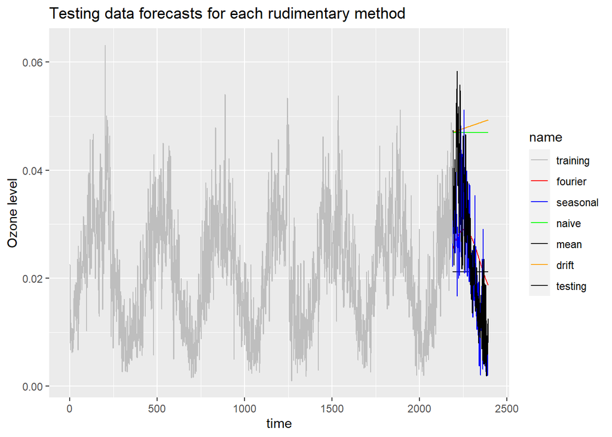

```
##                         ME       RMSE         MAE         MPE      MAPE
## Training set  1.119233e-05 0.00617968 0.004652142   -8.148316  29.22546
## Test set     -2.175616e-02 0.02532802 0.022415887 -178.319916 179.53443
##                   MASE       ACF1 Theil's U
## Training set 0.5772335 -0.2060367        NA
## Test set     2.7813430  0.8975027  6.480523
```

```
##                        ME        RMSE         MAE        MPE     MAPE      MASE
## Training set 0.0002238312 0.010519992 0.008059375 -21.191553 53.67716 1.0000000
## Test set     0.0028158824 0.009937143 0.007431745   2.670387 33.75856 0.9221242
##                   ACF1 Theil's U
## Training set 0.6648372        NA
## Test set     0.5877821  1.317463
```

```
##                         ME       RMSE         MAE        MPE      MAPE
## Training set -5.227143e-19 0.00617967 0.004652494   -8.22614  29.24126
## Test set     -2.290338e-02 0.02660189 0.023527878 -187.42343 188.57238
##                   MASE       ACF1 Theil's U
## Training set 0.5772773 -0.2060367        NA
## Test set     2.9193178  0.9049660  6.821126
```

```
##                         ME       RMSE         MAE       MPE     MAPE     MASE
## Training set -3.902385e-20 0.01054949 0.008757039 -47.26716 73.28424 1.086565
## Test set      4.060997e-03 0.01358933 0.010945592 -25.43844 64.28772 1.358119
##                   ACF1 Theil's U
## Training set 0.8271383        NA
## Test set     0.8975027  2.338047
```

```
##                         ME        RMSE         MAE       MPE     MAPE     MASE
## Training set -1.312801e-19 0.009637958 0.007797381 -38.85785 62.74710 0.967492
## Test set     -4.985024e-04 0.010923330 0.008944852 -40.66091 60.45414 1.109869
##                   ACF1 Theil's U
## Training set 0.7928874        NA
## Test set     0.8577406   2.17209
```

Here, we will use the RMSE and MAE as measures for assessing rank of performance of forecast starting from best (1) to worst (5). The order goes like this: with the lowest RMSE/MAE, we have 1. snaive 2. fourier 3. mean 4. naive 5. drift. This goes with the eye test as well, as the seasonal naive and fourier forecasts seem to capture much more of the seasonality in the data than the other forecasting methods, which probably leads to lower MAE for the better, more seasonal models.